# Two Faces of the Moon

Pink Floyd’s Evolution Before and After Syd Barrett

Author

Sepehr Akbari

Published

December 11, 2024

Research Focus

How did Syd Barrett’s departure shape the evolution of Pink Floyd’s sound, as reflected in key musical features, and what does this reveal about the band’s artistic transformation?

## Echoes of Change

Music evolves as a reflection of the forces shaping its creators. Pink Floyd is a prime example of how external and internal changes influence artistic direction. Syd Barrett, the band’s original creative mastermind, is widely credited with shaping their early identity as a psychedelic rock band. However, his departure in 1968 due to mental health struggles marks a profound turning point in their history [^1].

In this project, I investigate whether this transformation can be quantified through measurable changes in their music. Specifically, I analyze the energy levels of their songs, a Spotify-defined metric that captures the intensity and activity [^2] of a track. Energy is a useful proxy for several other musical attributes, such as mood, tempo, and instrumental variation, making it an ideal choice for tracing Pink Floyd’s evolution.

I’ll focus on the following hypotheses to guide this analysis:

- **Null Hypothesis ($H_0$):** There is no significant difference in energy between Pink Floyd’s pre- and post-Barrett eras.
- **Alternative Hypothesis ($H_1$):** There is a significant decrease in energy between Pink Floyd’s pre- and post-Barrett eras.

Through this lens, I aim to uncover how Barrett’s absence shaped the band’s artistic trajectory and influenced their broader legacy in music history.

## Breathe (In the Data)

```
packages & libraries
```

```r
library(gt) # for creating neater tables
library(here) # for managing file paths
library(tidyverse) # for data manipulation and visualization
library(splines) # for spline-based regression
```

```
loading data
```

```r
path <- here("Data", "PinkFloyd.csv") # path to the dataset
pink_floyd <- read_csv(path) # loading the dataset[^1]
```

The Dataset is downloaded from Kaggle [^3], and originally sourced from the Spotify Web API.

## Obscured by Data

Before diving into the analysis, I need to prepare the dataset. First, I enrich it by adding the release year for each album [^4]. This allows me to place each album within its historical context and track changes over time.

```
adding dates
```

```r
pink_floyd <- pink_floyd %>%
  # Creating new column for release year
  mutate(Year = case_when( # Assigning release years to albums
    Album_Name == "The Piper at the Gates of Dawn" ~ 1967,
    Album_Name == "A Saucerful of Secrets" ~ 1968,
    Album_Name == "More" ~ 1969,
    Album_Name == "Ummagumma" ~ 1969,
    Album_Name == "Atom Heart Mother" ~ 1970,
    Album_Name == "Meddle" ~ 1971,
    Album_Name == "Obscured by Clouds" ~ 1972,
    Album_Name == "The Dark Side of the Moon" ~ 1973,
    Album_Name == "Wish You Were Here" ~ 1975,
    Album_Name == "Animals" ~ 1977,
    Album_Name == "The Wall" ~ 1979,
    Album_Name == "The Final Cut" ~ 1983,
    Album_Name == "A Momentary Lapse of Reason" ~ 1987,
    Album_Name == "The Division Bell" ~ 1994,
    Album_Name == "The Endless River" ~ 2014
  ))
```

Next, I filter out albums released after 1985. Pink Floyd’s history can be divided into distinct phases, and my focus is on the band as it existed during its most cohesive period. Roger Waters’ departure in 1985 [^5] represents another major shift, making it logical to exclude albums from this later era to maintain a consistent scope for the analysis.

```
filtering albums
```

```r
pink_floyd <- pink_floyd %>%
  filter(Year < 1985) # Including only albums released before 1985
```

Finally, I categorize the albums into two eras: pre- and post-Barrett. Albums such as *More (1969)*, which bear Barrett’s stylistic influence even though he did not actively contribute to them [^6], are included in the pre-Barrett era. Meanwhile, *Ummagumma (1969)* is excluded because it is more of an experimental solo effort by the band members than a cohesive Pink Floyd album [^7]. These decisions ensure that my analysis is focused and aligned with the research question.

```
defining eras
```

```r
pre_barrett_albums <- c("The Piper at the Gates of Dawn",
                        "A Saucerful of Secrets",
                        "More") # Albums with Barrett's influence

pink_floyd <- pink_floyd %>%
  filter(Album_Name != "Ummagumma") %>% # Excluding Ummagumma
  mutate(Era = case_when( # Categorizing albums into pre- and post-Barrett eras
    Album_Name %in% pre_barrett_albums ~ "Pre-Barrett",
    TRUE ~ "Post-Barrett"
  ))
```

## Pulses of Evolution

To understand the band’s evolution, I calculate the average energy levels of their albums. This is important because Pink Floyd is known for their album-wide storytelling, where each track contributes to a larger narrative. So it makes sense to focus on the album as a whole rather than individual songs.

```
album averages
```

```r
pink_floyd_albums <- pink_floyd %>%
  group_by(Album_Name,
           Year,
           Era) %>% # Grouping by album, year and era
  summarize(Avg_Energy = mean(Energy)) # Calculating average energy levels for each
```

To get a visual sense of how energy levels have changed over time, I plot the data using a boxplot, which shows the distribution of energy levels for each era.

```
tidying data
```

```r
pink_floyd_albums_tidy <- pink_floyd_albums %>%
  # Having each row represent a single observation about Features
  pivot_longer(cols = Avg_Energy,
               names_to = "Feature",
               values_to = "Value")
```

```
visualizing data
```

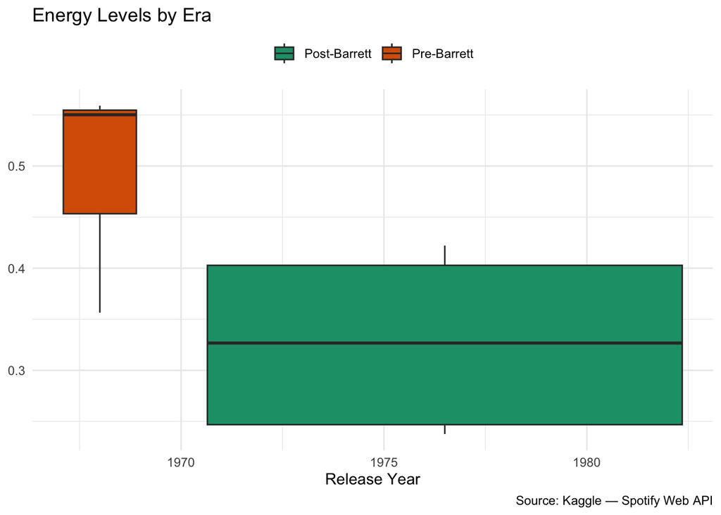

```r
ggplot(
  pink_floyd_albums_tidy,
  aes(x = Year,
      y = Value,
      fill = Era) # Coloring by era
) +
  geom_boxplot() + # Creating boxplot
  labs(
    title = "Energy Levels by Era",
    x = "Release Year",
    y = NULL,
    fill = NULL,
    caption = "Source: Kaggle — Spotify Web API" # citing the source
  ) +
  theme_minimal() + # For a clear look
  theme(legend.position = "top") + # For aesthetics only
  scale_fill_brewer(palette = "Dark2") # For accessible colors
```

This initial plot shows how the Pre-Barrett era is characterized by consistently higher and more narrowly distributed energy levels, while the Post-Barrett era shows greater variability and a lower median energy level. This shift reflects the band’s transition from Barrett’s psychedelic influence to more experimental and diverse styles. However, the story is not linear. To capture the nuanced evolution of energy levels over time, I fit a spline regression curve to the data, visualizing the rise and fall of energy across the years.

```
visualizing data
```

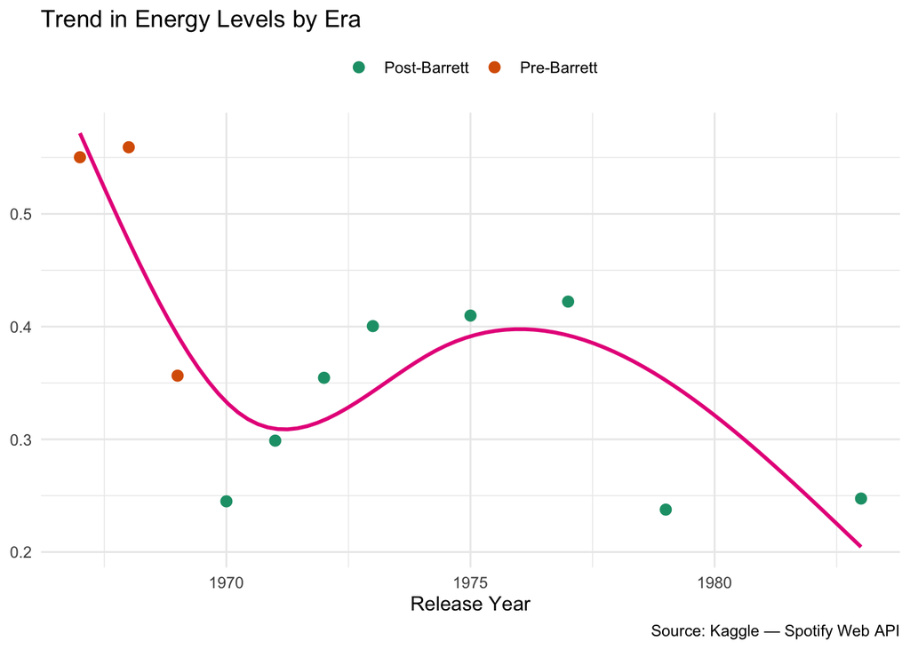

```r
ggplot(
  pink_floyd_albums_tidy,
  aes(x = Year,
      y = Value)
  ) +
  geom_point(aes(color = Era), # Coloring points by era
             size = 2.5 # For aesthetics only
  ) +
  geom_smooth(show.legend = FALSE, # There is only one line
              se = FALSE, # Removing error ribbon
              method = "lm", # Using a model
              formula = y ~ ns(x, 3), # Using natural splines for flexibility
              color = "#e7298a" # From Dark2 Palette for accessibility
  ) +
  labs(
    title = "Trend in Energy Levels by Era",
    x = "Release Year",
    y = NULL,
    color = NULL,
    caption = "Source: Kaggle — Spotify Web API" # citing the source
  ) +
  theme_minimal() + # For a clear look
  scale_color_brewer(palette = "Dark2") + # For accessible colors
  theme(legend.position = "top") # For aesthetics only
```

```
calculating mean
```

```r
mean_albums <- mean(pink_floyd_albums$Avg_Energy) # Calculating overall average energy level
```

```
visualizing data
```

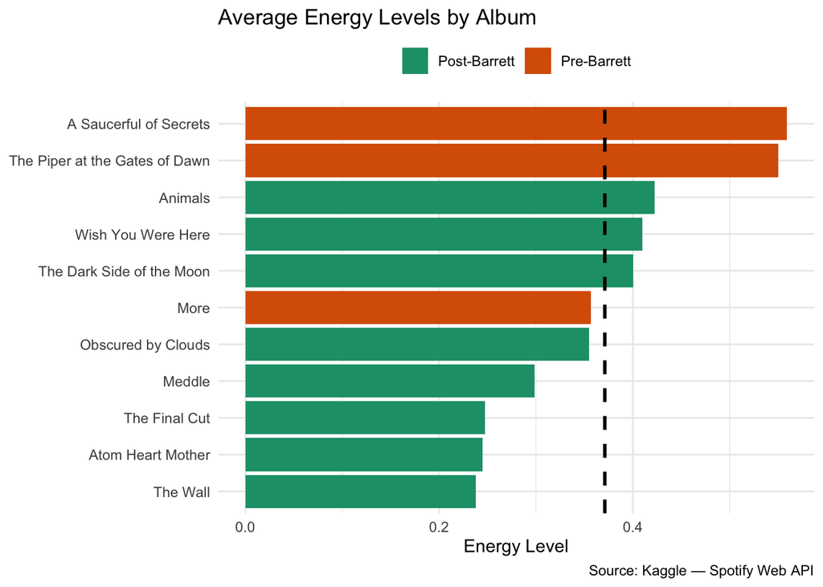

```r
ggplot(
  pink_floyd_albums,
  aes(x = Avg_Energy,
      y = reorder(Album_Name,
                  Avg_Energy), # Ordering by energy level
      fill = Era) # Coloring by era
) +
  geom_col() + # Creating bar plot
  geom_vline(xintercept = mean_albums, # Adding a vertical line for overall average
             linetype = "dashed",
             size = 1 # Aesthetics only
  ) +
  labs(
    title = "Average Energy Levels by Album",
    x = "Energy Level",
    y = NULL,
    fill = NULL,
    caption = "Source: Kaggle — Spotify Web API" # citing the source
  ) +
  theme_minimal() + # For a clear look
  scale_fill_brewer(palette = "Dark2") + # For accessible colors
  theme(legend.position = "top") # For aesthetics only
```

This ranking underscores the dominance of Pre-Barrett albums like *The Piper at the Gates of Dawn* and *A Saucerful of Secrets*, which sit at the high-energy end of the spectrum. Conversely, albums from the later Post-Barrett era, such as *The Wall* and *The Final Cut*, are situated at the lower-energy end, reflecting the band’s shift toward somber and reflective themes. Interestingly, the album *More* is at a unique position, aligning almost perfectly with the overall average energy level. This highlights its transitional nature as the band navigated Barrett’s absence and explored new creative directions.

These patterns provide a strong understanding of Pink Floyd’s evolution, matching our hypotheses of a decrease in energy levels. But to rigorously evaluate the differences between the Pre-Barrett and Post-Barrett eras, we must turn to statistical significance testing.

## A Momentary Lapse or Statistical Certainty?

Visual trends are compelling, but statistical evidence is essential to confirm whether the observed differences in energy levels are meaningful. To test my hypothesis, I first calculated the average energy levels for each era.

```
calculating averages
```

```r
pink_floyd_era <- pink_floyd %>%
  group_by(Era) %>% # Grouping by era
  summarize(Avg_Energy = mean(Energy)) # Calculating average energy levels
```

```
displaying data
```

```r
pink_floyd_era %>%
  gt() %>%  # For a nicer table
  tab_header(title = "Average Energy Levels by Era") %>%
  cols_label(Era = "Era",
             Avg_Energy = "Average Energy Level") # Aesthetic stuff
```

Average Energy Levels by Era

| Era | Average Energy Level |
| --- | --- |
| Post-Barrett | 0.3067324 |
| Pre-Barrett | 0.4710032 |

```
performing t-test
```

```r
# Defining energy levels column for each era
pre_barrett <- pink_floyd$Energy[pink_floyd$Era == "Pre-Barrett"]
post_barrett <- pink_floyd$Energy[pink_floyd$Era == "Post-Barrett"]

# Performing two-sample t-test
t.test(pre_barrett, post_barrett)
```

```
    Welch Two Sample t-test

data:  pre_barrett and post_barrett
t = 3.5033, df = 45.709, p-value = 0.00104
alternative hypothesis: true difference in means is not equal to 0
95 percent confidence interval:
 0.06987039 0.25867120
sample estimates:
mean of x mean of y
0.4710032 0.3067324
```

These results allow me to confidently **reject the null hypothesis** that there is no difference in energy levels between the two eras. With a p-value of 0.00104, well below the threshold of 0.05, this analysis confirms that the observed reduction in energy levels is statistically significant and unlikely to be due to random chance. This suggests a genuine shift in Pink Floyd’s musical style between the eras.

The t-statistic of 3.503, a measure of how much the observed difference deviates from the expectation under the null hypothesis, indicates a strong separation between the energy levels of the two eras. In real terms, this reflects a marked departure from the spontaneous, high-energy sounds to the more introspective and deliberate compositions. The confidence interval, ranging from 0.0699 to 0.2587, provides a plausible range for the true difference in mean energy levels. So even in the most conservative estimate, the reduction in energy levels remains meaningful, reinforcing the impact of the shift.

## The Final Cut

Pink Floyd’s evolution after Syd Barrett’s departure is marked by a significant decline in energy levels, reflecting a clear shift from Barrett’s vibrant and spontaneous psychedelic influence to the band’s more introspective and experimental themes. Energy, used here as a proxy for intensity, mood, and instrumental texture, reveals not just a stylistic change but a broader transformation in their approach to music. This decline highlights how the band moved away from Barrett’s raw and lively sound to explore layered, contemplative compositions that defined their later works.

While the data confirms a sharp, and significant reduction in energy, this transformation cannot be solely attributed to Barrett’s absence. Significance does not imply causation. External factors, including the maturation of progressive rock as a genre and the band’s artistic growth, undoubtedly influenced this evolution. Still, Barrett’s departure served as a catalyst, prompting Pink Floyd to adapt and innovate in response to this pivotal moment.

Ultimately, the observed decline in energy levels underscores Pink Floyd’s journey from a band rooted in Barrett’s influence to one that redefined itself through reinvention and resilience. By focusing on energy as a central feature, this analysis reveals how Barrett’s departure shaped the band’s artistic trajectory, paving the way for their legacy as one of rock’s most innovative and enduring acts.

## Footnotes

[^1]: [Pink Floyd Wikipedia](https://en.wikipedia.org/wiki/Pink_Floyd)
[^2]: [Spotify Web-API Docs](https://developer.spotify.com/documentation/web-api/reference/get-audio-features)
[^3]: [Pink Floyd Audio Features](https://www.kaggle.com/datasets/thebumpkin/pink-floyd-all-the-tracks-with-spotify-data/data)
[^4]: [UCR: Pink Floyd Discography](https://ultimateclassicrock.com/pink-floyd-album-discography/)
[^5]: [Pink Floyd’s Break Up](https://otherbrick.com/why-did-pink-floyd-break-up/)
[^6]: [SputnikMusik: More Album Review](https://www.sputnikmusic.com/review/88783/Pink-Floyd-More/)
[^7]: [SputnikMusik: Ummagumma Album Review](https://www.sputnikmusic.com/review/88810/Pink-Floyd-Ummagumma/)